# R Notebook - Building Time Series Models for the Covid-19 dataset for India

**Loading the libraries**

**Loading the dataset**

*Function to role up the dataset at Country level to get the cumulative cases*

```r
total_cases <- function(cname)
{
  country <- train_data[train_data$Country_Region == cname,]

  new_cases <- country %>% dplyr::select(Date, ConfirmedCases) %>%
                              group_by(Date) %>%
                                mutate(TotalConfirmedCases = sum(ConfirmedCases)) %>%
                                  ungroup()%>%
                                    dplyr::select(Date, TotalConfirmedCases) %>%
                                      distinct() %>%
                                        dplyr::select(TotalConfirmedCases) %>%
                                          filter(TotalConfirmedCases > 0)
  #Reading the TS file
  original_ts <- as.ts((new_cases$TotalConfirmedCases))
  return(original_ts)
}
```

*Function to plot the the time series, ACF and PACF - inout argument ts_object*

```r
plot_ts <- function(ts_object)
{
  par(mfrow=c(1,3))
  plot(ts_object)
  acf(ts_object)
  pacf(ts_object)

}
```

#### Data is selected for India

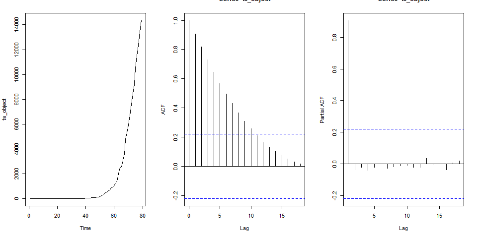

```r
india_cases_ts <- total_cases("India")
plot_ts(india_cases_ts)
```

From the time series plot we see that there is an upward increasing trend, and hence it is non-stationary (as expected). The ACF is decaying slowly and the PACF cuts off after lag 1. From the plots it is evident that the series is not stationary. However we will perform the ADF test to prove it statistically

Augmented Dickey-Fuller Test - Null hypothesis, H0: There is a unit root, i.e., homogeneous nonstationarity. - Alternative hypothesis, H1: There is no unit root, i.e., stationarity.

Therefore, a small p-value would indicates stationarity and large p-value indicates homogeneous nonstationarity, i.e., there is a unit root.

The test statistic has a special distribution that is not commonly seen, so it make more sense to just look at the p-value.

```r
adf.test(india_cases_ts)
```

```
p-value greater than printed p-value
```

```
    Augmented Dickey-Fuller Test

data:  india_cases_ts
Dickey-Fuller = -0.15814, Lag order = 4, p-value = 0.99
alternative hypothesis: stationary
```

Since p-value is large, we fail to reject the Null hypothesis. This implies non-stationarity. Some order differential might be appropriate for this series

Plotting the time series for a larger time series.

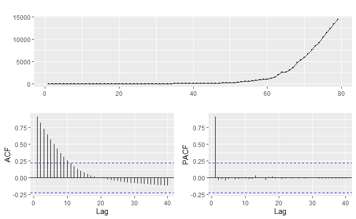

Creating a difference of the order 2 on the dataset and visualizing to glimpse at the plots

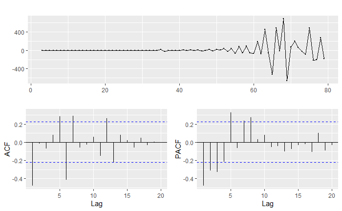

Taking second order differencing in order to make the series stationary -

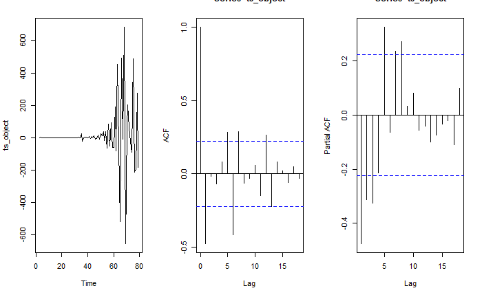

```r
india_cases_ts_diff <- india_cases_ts %>% diff(differences = 2)
plot_ts(india_cases_ts_diff)
```

```r
adf.test(india_cases_ts_diff)
```

```
p-value smaller than printed p-value
```

```
    Augmented Dickey-Fuller Test

data:  india_cases_ts_diff
Dickey-Fuller = -4.7132, Lag order = 4, p-value = 0.01
alternative hypothesis: stationary
```

Running a few model variations with individual diagnostics for the same

Auto ARIMA

```r
india_auto_fit_diff2 <- auto.arima(india_cases_ts_diff)
india_auto_fit_diff2
```

```
Series: india_cases_ts_diff
ARIMA(0,0,4) with non-zero mean

Coefficients:
          ma1     ma2      ma3     ma4     mean
      -0.8219  0.2291  -0.2848  0.5686  14.0905
s.e.   0.1063  0.1388   0.2319  0.1746   8.9758

sigma^2 estimated as 14370:  log likelihood=-476.77
AIC=965.54   AICc=966.74   BIC=979.6
```

```r
india_auto_fit <- auto.arima(india_cases_ts)
india_auto_fit
```

```
Series: india_cases_ts
ARIMA(1,2,2)

Coefficients:
         ar1      ma1     ma2
      0.7248  -1.6622  0.8629
s.e.  0.1596   0.0992  0.0578

sigma^2 estimated as 15647:  log likelihood=-480.7
AIC=969.4   AICc=969.96   BIC=978.78
```

```r
(1-pnorm(abs(auto_fit$coef)/sqrt(diag(auto_fit$var.coef))))*2
```

```
         ar1          ma1          ma2
5.591854e-06 0.000000e+00 0.000000e+00
```

```r
fit1 <- arima(india_cases_ts, order = c(2,2,2))
fit1
```

```
Call:
arima(x = india_cases_ts, order = c(2, 2, 2))

Coefficients:
         ar1      ar2      ma1     ma2
      0.5958  -0.3279  -1.5697  1.0000
s.e.  0.1112   0.1165   0.0666  0.0759

sigma^2 estimated as 13335:  log likelihood = -478.34,  aic = 966.69
```

```r
Box.test(fit1$residuals, lag = 10, fitdf = 4)
```

```
    Box-Pierce test

data:  fit1$residuals
X-squared = 15.759, df = 6, p-value = 0.01511
```

```r
checkresiduals(fit1)
```

```
    Ljung-Box test

data:  Residuals from ARIMA(2,2,2)
Q* = 17.398, df = 6, p-value = 0.007928

Model df: 4.   Total lags used: 10
```

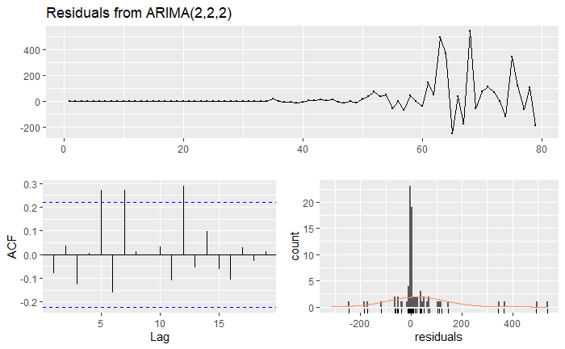

```r
par(mfrow=c(1,1))
```

```r
plot(india_cases_ts)
points(fitted(fit1), pch = 20, col = "grey")
```

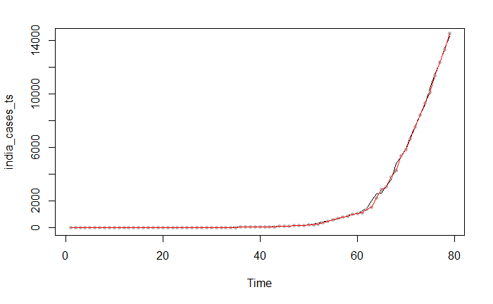

```r
points(fitted(fit1), type = "l", col = "red")
```

```r
fit2 <- arima(india_cases_ts, order = c(0,2,4))
fit2
```

```
Call:
arima(x = india_cases_ts, order = c(0, 2, 4))

Coefficients:
          ma1     ma2      ma3     ma4
      -0.8083  0.3156  -0.2058  0.6277
s.e.   0.2579  0.1616   0.2486  0.2544

sigma^2 estimated as 13177:  log likelihood = -477.83,  aic = 965.66
```

```r
Box.test(fit2$residuals, lag = 10, fitdf = 4)
```

```
    Box-Pierce test

data:  fit2$residuals
X-squared = 16.103, df = 6, p-value = 0.01321
```

```r
checkresiduals(fit2)
```

```
    Ljung-Box test

data:  Residuals from ARIMA(0,2,4)
Q* = 17.58, df = 6, p-value = 0.007371

Model df: 4.   Total lags used: 10
```

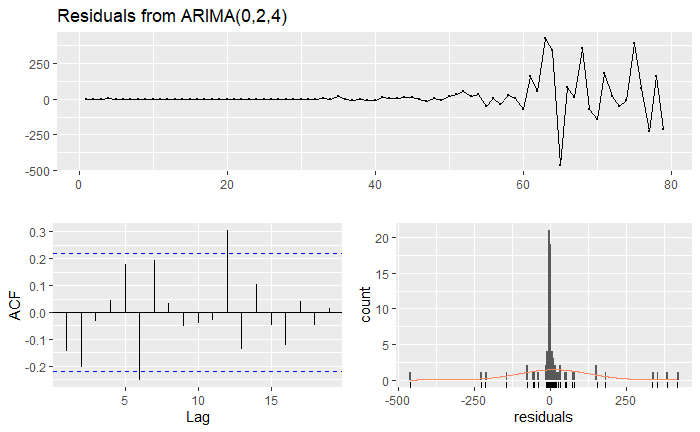

```r
par(mfrow=c(1,1))
```

```r
plot(india_cases_ts)
points(fitted(fit2), pch = 20, col = "grey")
```

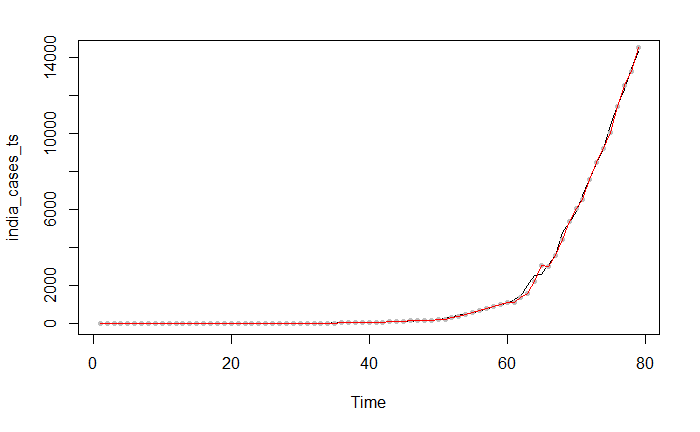

```r
points(fitted(fit2), type = "l", col = "red")
```

```r
fit3 <- arima(india_cases_ts, order = c(1,2,0))
fit3
```

```
Call:
arima(x = india_cases_ts, order = c(1, 2, 0))

Coefficients:
          ar1
      -0.4693
s.e.   0.1003

sigma^2 estimated as 22148:  log likelihood = -494.59,  aic = 993.19
```

```r
Box.test(fit3$residuals, lag = 10, fitdf = 1)
```

```
    Box-Pierce test

data:  fit3$residuals
X-squared = 33.608, df = 9, p-value = 0.0001046
```

```r
checkresiduals(fit3)
```

```
    Ljung-Box test

data:  Residuals from ARIMA(1,2,0)
Q* = 36.389, df = 9, p-value = 3.381e-05

Model df: 1.   Total lags used: 10
```

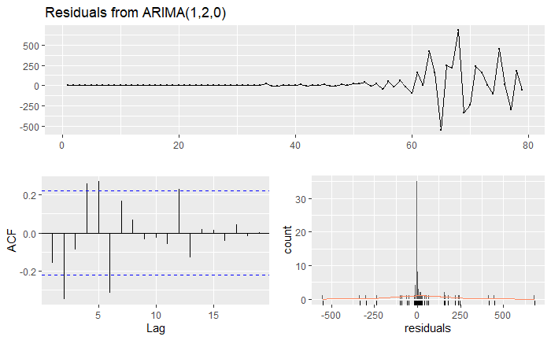

```r
par(mfrow=c(1,1))
```

```r
plot(india_cases_ts)
points(fitted(fit3), pch = 20, col = "grey")
```

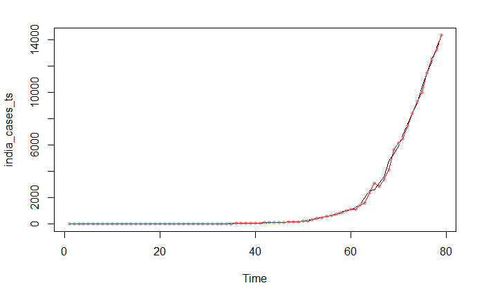

```r
points(fitted(fit3), type = "l", col = "red")
```

```r
(1-pnorm(abs(fit4$coef)/sqrt(diag(fit4$var.coef))))*2
```

```
         ar1          ar2          ma1          ma2          ma3          ma4
1.559583e-01 4.088411e-06 5.018208e-14 0.000000e+00 9.192647e-13 2.138290e-13
```

```r
fit5 <- arima(india_cases_ts, order = c(4,2,4))
fit5
```

```
Call:
arima(x = india_cases_ts, order = c(4, 2, 4))

Coefficients:
          ar1      ar2      ar3      ar4      ma1      ma2     ma3     ma4
      -0.8184  -0.2631  -0.1189  -0.4632  -0.1170  -0.3235  0.0200  0.9119
s.e.   0.1338   0.1638   0.1646   0.1278   0.1118   0.1462  0.1595  0.1141

sigma^2 estimated as 11033:  log likelihood = -471.78,  aic = 961.56
```

```r
Box.test(fit5$residuals, lag = 10, fitdf = 8)
```

```
    Box-Pierce test

data:  fit5$residuals
X-squared = 10.603, df = 2, p-value = 0.004985
```

```r
checkresiduals(fit5)
```

```
    Ljung-Box test

data:  Residuals from ARIMA(4,2,4)
Q* = 11.887, df = 3, p-value = 0.007781

Model df: 8.   Total lags used: 11
```

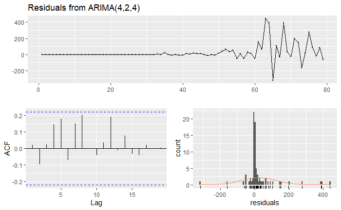

```r
par(mfrow=c(1,1))
```

```r
plot(india_cases_ts)
points(fitted(fit5), pch = 20, col = "grey")
```

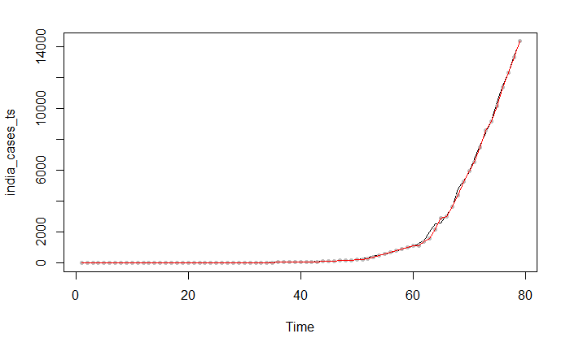

```r
points(fitted(fit5), type = "l", col = "red")
```

Forecast for both the models

[output not shown]

```r
forecast(auto_fit, h = 10)

forecast(fit4, h = 10)
```

|  | Point Forecast | Lo 80 | Hi 80 | Lo 95 | Hi 95 |
| --- | --- | --- | --- | --- | --- |
| 80 | 15621.16 | 15489.78 | 15752.54 | 15420.24 | 15822.09 |
| 81 | 16568.45 | 16374.31 | 16762.60 | 16271.53 | 16865.38 |
| 82 | 17686.33 | 17408.15 | 17964.50 | 17260.90 | 18111.76 |
| 83 | 18758.84 | 18409.19 | 19108.49 | 18224.10 | 19293.58 |
| 84 | 19751.05 | 19267.95 | 20234.14 | 19012.22 | 20489.88 |
| 85 | 20778.24 | 20110.48 | 21446.01 | 19756.98 | 21799.50 |
| 86 | 21841.23 | 20987.29 | 22695.17 | 20535.24 | 23147.21 |
| 87 | 22881.09 | 21832.42 | 23929.75 | 21277.29 | 24484.88 |
| 88 | 23906.11 | 22637.96 | 25174.26 | 21966.64 | 25845.58 |
| 89 | 24945.11 | 23439.95 | 26450.27 | 22643.17 | 27247.06 |

Additional Code

Taking a log transform of the data

```r
india_cases_ts %>% log() %>% ggtsdisplay(lag.max=40)
```

[output not shown]

```r
india_cases_ts %>% log() %>% diff() %>% ggtsdisplay(lag.max=40)
```

[output not shown]

```r
auto.arima(india_cases_ts)
```

```
Series: india_cases_ts
ARIMA(1,2,2)

Coefficients:
         ar1      ma1     ma2
      0.7248  -1.6622  0.8629
s.e.  0.1596   0.0992  0.0578

sigma^2 estimated as 15647:  log likelihood=-480.7
AIC=969.4   AICc=969.96   BIC=978.78
```

```r
arima(india_cases_ts, order = c(2,2,2))
```

```
Call:
arima(x = india_cases_ts, order = c(2, 2, 2))

Coefficients:
         ar1      ar2      ma1     ma2
      0.5958  -0.3279  -1.5697  1.0000
s.e.  0.1112   0.1165   0.0666  0.0759

sigma^2 estimated as 13335:  log likelihood = -478.34,  aic = 966.69
```

```r
total_cases_new <- function(cname)
{
  country <- train_data[train_data$Country_Region == cname,]

  new_cases <- country %>% dplyr::select(Date, ConfirmedCases) %>%
                              group_by(Date) %>%
                                mutate(TotalConfirmedCases = sum(ConfirmedCases)) %>%
                                  ungroup()%>%
                                    dplyr::select(Date, TotalConfirmedCases) %>%
                                      distinct() %>%
                                          filter(TotalConfirmedCases > 0)

  #Reading the TS file
  return(new_cases)
}
```